# Bruhn_C02_2

$$P = \frac{48EI}{5L^3} = \frac{9.6\,EI}{L^3}$$

これはオイラーの式の $P = 9.9\,EI/L^3$ と比較して、3パーセントの誤差に相当する。

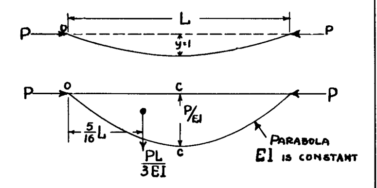

Fig. C2.20

不均一な断面を持つ柱に対しても、同様の手順を適用することができる。中心点に対して対称な柱についてのこの手順のステップは以下の通りである。

1. 中心点において単位たわみを持つ、たわんだ柱の正弦曲線を仮定する。
2. 柱の断面積に対する慣性モーメント ( $I$ ) 曲線を作図する。
3. 端部荷重 $P$ に横方向のたわみを乗じたものによる曲げモーメント曲線を求める。
4. これらのモーメント値を $EI$ 値で除して $M/EI$ 曲線を得る。弾性係数 $E$ は一定とみなされる。
5. この $M/EI$ 荷重による柱のたわみ曲線を求める。
6. 得られた柱のたわみ曲線の形状を、最初に正弦曲線として仮定したものと比較する。これは、計算されたたわみに、中心のたわみを 1 にするような係数を乗じることによって行うことができる。仮定された正弦曲線は実際の柱のたわみ曲線ではないため、計算されたたわみは正弦曲線とは多少異なる。
7. 中心点において 1 となるように修正された計算たわみ曲線を用いて、ステップ (3)、(4)、(5) および (6) を繰り返す。今回の結果は、得られたたわみ曲線が仮定したたわみ曲線にさらに近づくことを示す。
8. 所望の精度を得るために、ステップ (7) の手順は通常、再度繰り返される必要がある。
9. 中心点におけるたわみを 1 と等しく置くことによって、荷重 $P$ に対する式を書き、それを解く。これは、一様断面の柱を含む前述の例題で行われたように、モーメント面積法を用いることによって行われる。

上記で概説した手順では、 $E$ は一定であると仮定されている。言い換えれば、柱の破壊は弾性的であるか、あるいは破壊応力が材料の比例限度応力以下である。実際の骨組問題は通常、非弾性曲げによって破壊が生じる細長比を含んでおり、したがって $E$ は一定ではない。この場合、非弾性応力範囲において応力とともに変化する正接弾性係数を用いて、試行錯誤による解法が必要となる。

## C2.7 不均一断面を持つ柱の設計柱曲線

Fig. C2.21 および Fig. C2.22 は、2種類のアタッチメント付き（段付き）柱の迅速な解決のための曲線を与えている。Fig. C2.23 および Fig. C2.24 は、2種類のテーパー付き柱の迅速な解決のための曲線を与えている。これらの曲線の使用法については、本章の後半で説明する。

## C2.8 弾性横拘束および既知の端部曲げ拘束を持つ柱に使用する柱固定度係数 c

Fig. C2.25 および Fig. C2.26 は、1つおよび2つの弾性横拘束を持つ柱の固定度係数 $c$ を求めるための曲線を与え、Fig. C2.27 は、柱端部における拘束モーメントが既知である場合の $c$ を求めるための曲線を与えている。これらの様々な曲線の使用法については、後半で説明する。

## C2.10 例題

### 問題 1.

Fig. C2.29 は、長さ 30 インチの鍛造 (I) 断面部材を示しており、これは圧縮部材として使用される。

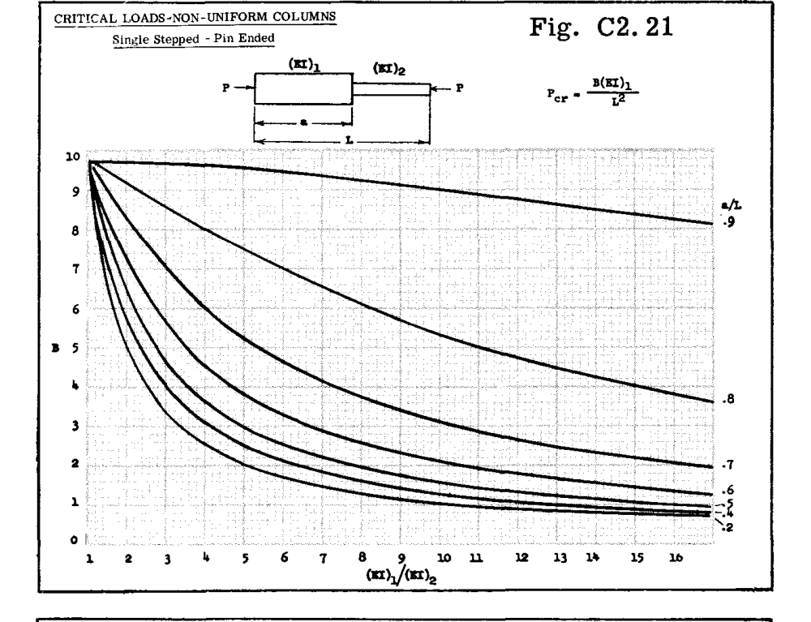

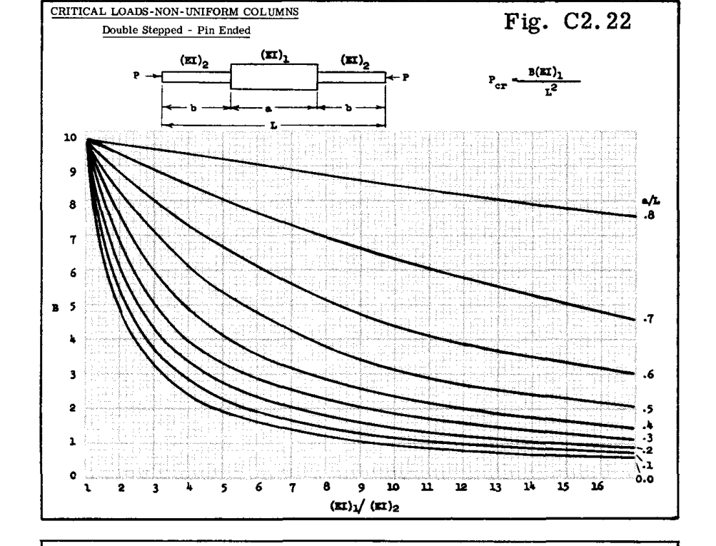

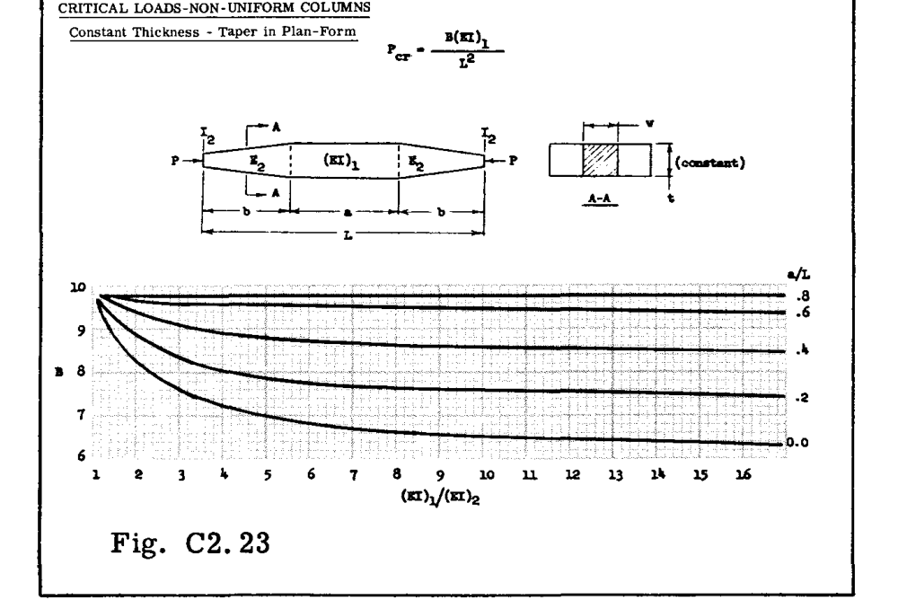

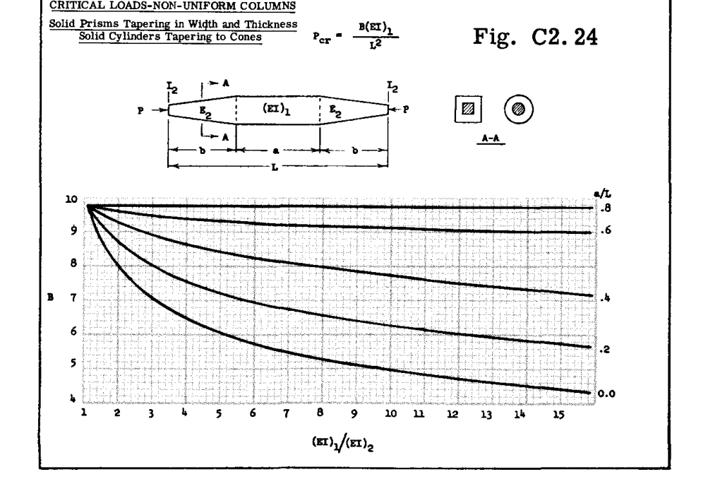

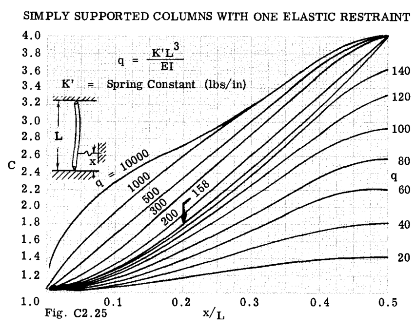

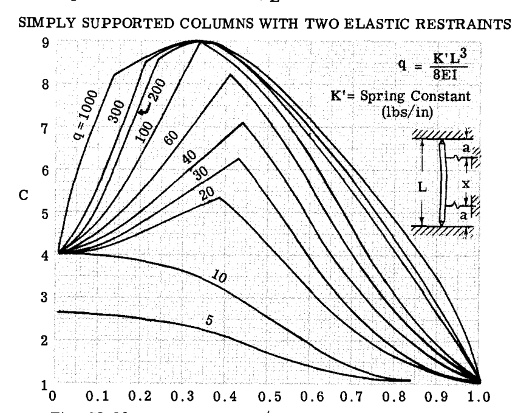

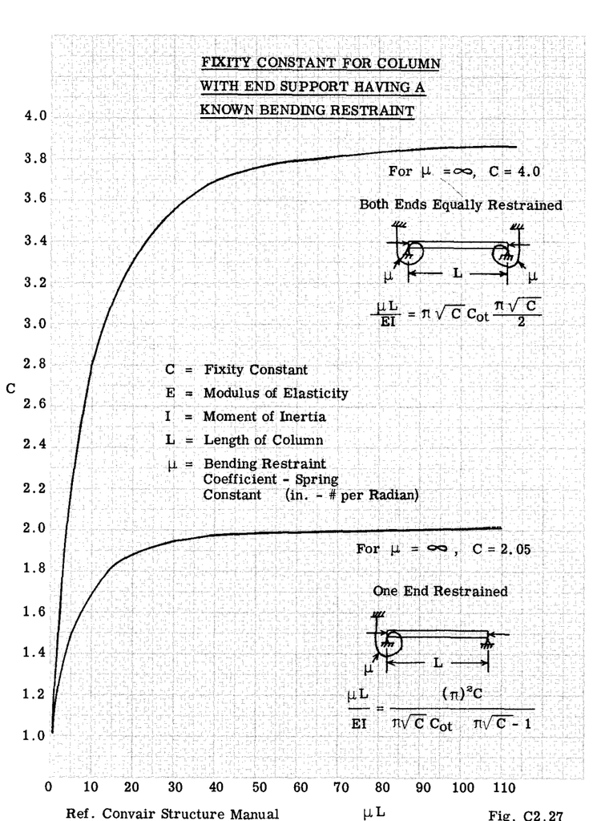

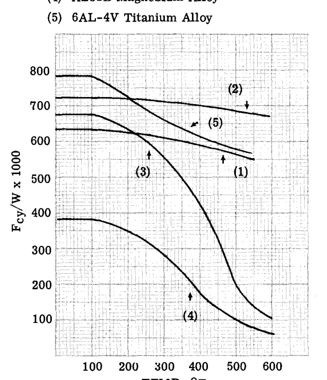

Fig. C2.28

次の材料で製造され、指定された温度と時間の条件にさらされた場合の部材の極限強度を求めよ。

ケース 1. 材料 7079-T6 アルミ合金手打ち鍛造、室温。

ケース 2. ケース 1 と同様、ただし 300°F の温度に 1/2 時間さらされたもの。

ケース 3. ケース 2 と同様、ただし 600°F の場合。

ケース 4. 材料 17-4 PH ステンレス鋼、手打ち鍛造、室温。

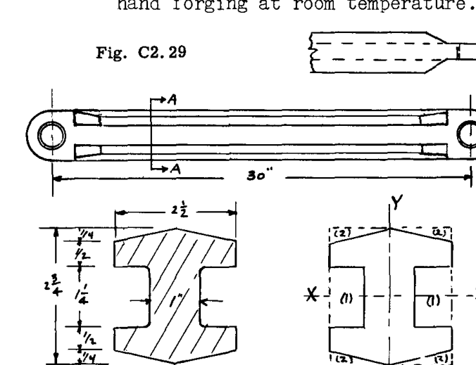

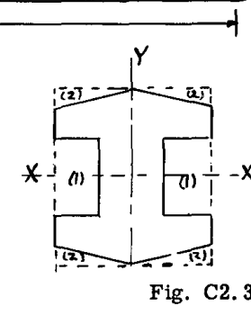

### 解答：

柱は $X$ 軸または $Y$ 軸のいずれかを中心とした曲げによって破壊する可能性があるため、これらの軸のそれぞれを中心とした曲げに対する柱強度を計算する。柱強度は断面の回転半径の関数であるため、解法の第一ステップは $I_x$ および $I_y$ の計算であり、これらから $\rho_x$ および $\rho_y$ を求めることができる。

$I_x$ の計算： Fig. C2.30 において、断面は最初に $2.5 \times 2.75$ のソリッドな長方形と考えられ、その後、部分 (1) および (2) の特性が差し引かれる。

$$I_x (\text{rectangle}) = \frac{1}{12} \times 2.5 \times 2.75^3 = 4.32$$

部分 (1) および (2)

$$I_x = -\frac{1}{12} \times 1.5 \times 1.25^3 - 4(0.625 \times 0.25 \times 1.292^2) = -1.29$$

（(2) のその $x$ 図心軸まわりの $I_o$ は無視できる）

$$I_x = 4.32 - 1.29 = 3.03\,\text{in.}^4$$

$$\rho_x = \sqrt{\frac{I_x}{A}}$$

$$\text{面積 } A = 2.5 \times 2.75 - 2 \times 0.75 \times 1.25 - 4 \times 0.25 \times 0.625 = 4.375\,\text{sq. in.}$$

$$\rho_x = \sqrt{3.03 / 4.375} = 0.83\,\text{in.}$$

$I_y$ の計算：

$$I_y (\text{solid}) = \frac{1}{12} \times 2.75 \times 2.5^3 = 3.58$$

$$\text{部分 (1)} = -(1.25 \times 0.75 \times 0.875^2) \times 2 - (1.25 \times 0.75^3 / 12) \times 2 = -1.52$$

$$\text{部分 (2)} = -(0.25 \times 0.625 \times 0.833^2) \times 4 - 4(0.25 \times 1.25^3 / 36) = -0.488$$

$$I_y = 3.58 - 1.52 - 0.488 = 1.58\,\text{in.}^4$$

$$\rho_y = \sqrt{1.58 / 4.375} = 0.60\,\text{in.}$$

柱強度は端部拘束条件によってかなり影響を受ける。 $x-x$ 軸まわりの曲げによる破壊については、単一のフィッティングボルトが $x-x$ 軸に平行な軸を持っているため、回転に対する端部拘束はゼロであり、したがって固定度係数 $c$ は 1 である。 $y-y$ 軸まわりの曲げによる破壊については、ボルトおよび隣接するフィッティングと構造物の剛性に依存する端部拘束がある。この例題では、この拘束は端部固定度係数 $c = 1.5$ となるようなものである。

$x-x$ 軸まわりの破壊に対して、

$$L' = L/\sqrt{c} = 30/\sqrt{1} = 30, \quad L'/\rho_x = 30/0.83 = 36$$

$y-y$ 軸まわりの破壊に対して、

$$L' = 30/\sqrt{1.5} = 24.6, \quad L'/\rho_y = 24.6/0.60 = 41$$

したがって、破壊は $y-y$ 軸まわりの曲げに対して致命的であり、 $L' / \rho = 41$ である。

ケース 1. 材料は 7079-T6 アルミ合金手打ち鍛造である。Fig. C2.14 は、この材料の破壊応力 $F_c$ を $L'/\rho$ 比に対してプロットしたものである。したがって、 $L'/\rho = 41$ および室温曲線を用いると、 $F_c = 50,500\,\text{psi}$ と読み取れる。したがって、破壊荷重は $P = F_c A = 50,500 \times 4.375 = 220,000\,\text{lbs}$ である。

ケース 2. Fig. C2.14 の 300°F 曲線を用いて、同じ $L' / \rho$ 値に対して $F_c = 40,400$ を読み取り、したがって $P = 40,400 \times 4.375 = 177,000\,\text{lbs}$ となる。

ケース 3. 600°F 曲線を用いると、 $F_c$ は 6100 を読み取り、したがって $P = 6100 \times 4.375 = 26,700\,\text{lbs}$ となる。このように、この部材を 600°F の温度に 1/2 時間さらすと、その強度は 220,000 から 26,700 lbs に低下する。これは、このような温度下で荷重を支持する場合、アルミ合金は強度の低下が非常に大きいため、不適切な材料であることを意味している。

ケース 4. 材料は 17-4 PH ステンレス鋼鍛造である。Fig. C2.8 は、この材料の柱曲線を与えている。 $L'/\rho = 41$ に対し、室温曲線を用いて $F_c = 135,200$ を読み取り、したがって $P = 135,200 \times 4.375 = 591,000\,\text{lbs}$ となる。

## C2.10 柱曲線を使用しない解法

一次曲げ破壊が比例限度応力を超える応力で発生する場合、破壊応力は次式 (5) によって与えられる。

$$F_c = \frac{\pi^2 E_t}{(L'/\rho)^2}$$

$E_t$ は正接弾性係数であるため、 $F_c$ に応じて変化し、したがって式を解く前に $E_t$ と $F_c$ の関係を知る必要がある。多くの製造形態のすべての材料について、さらに様々な温度条件を加えた柱曲線を作図するには、数百の個別の柱チャートが必要となる。このような曲線の使用は、Ramsburg と Osgood によって提示され、Cozzone と Melcon によって拡張された（章 C2.4 および C2.5 参照）、柱設計に使用するための材料に関するいくつかの値またはパラメータを知っていれば、回避することができる。

したがって、Fig. C2.17 の曲線を利用する。

ケース 1. 材料 7079-T6 アルミ合金鍛造。第 Bl 章の Table B1.1 は、特定の材料特性を要約している。Fig. C2.17 を使用するために必要な特性は、形状因子 $n$ 、係数 $E_c$ 、および応力 $F_{o.7}$ である。Table B1.1 を参照すると、 $n = 26$ 、 $E_c = 10,500,000$ 、および $F_{o.7} = 59,500$ であることがわかる。

Fig. C2.17 の横軸は次のパラメータを含んでいる。

$$B = \frac{1}{\pi} \sqrt{\frac{F_{o.7}}{E_c}} (L'/\rho)$$

代入すると：

Fig. C2.17 を下部目盛の 1.01 で使用し、 $n = 26$ 曲線まで垂直に投影し、次にチャートの左側にある目盛まで水平に投影すると、 $F_c/F_{o.7} = 0.842$ が読み取れる。

その場合、 $F_c = 59,500 \times 0.842 = 50,100$ となり、Fig. C2.14 を使用した前述の解法における 50,500 と比較される。

その場合、

$$B = \frac{1}{\pi} \sqrt{\frac{46,500}{9,400,000}} (41) = 0.917$$

$B = 0.917$ および $n = 29$ に対する Fig. C2.17 から、 $F_c/F_{o.7} = 0.88$ を読み取り、したがって $F_c = 46,500 \times 0.88 = 40,900$ となり、前述の解法における 40,400 と比較される。

### 例題 2.

Fig. C2.31 は、押出 (I) 断面を示している。この断面からなる部材は長さ 32 インチである。部材は $x$ 方向に横方向支持されているため、破壊は $x-x$ 軸まわりの曲げによって発生する。部材はピン支持端であり、したがって $c = 1$ である。材料は 7075-T6 押出材である。問題は、室温条件下における破壊応力 $F_c$ を求めることである。

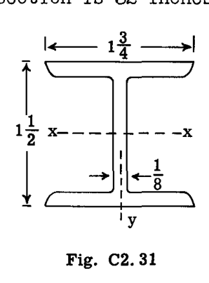

Fig. C2.31

この (I) 断面は、第 A3 章の Table A3.15 における Section 15 に対応している。このテーブルを参照すると、次のようになる。

$$A = 0.594\,\text{sq. in.}, \quad \rho_x = 0.618$$

$$L' = L, \quad \sin c = 1, \quad L'/\rho_x = 32 / 0.618 = 51.7$$

部材が 450°F の温度に 1/2 時間さらされる場合を考える。 Fig. C2.11 から、 $F_c = 21,400\,\text{psi}$ である。

Fig. C2.17 を使用すると： Table B1.1 から、 $n = 8.8$ 、 $E_c = 7,800,000$ 、および $F_{o.7} = 29,000$ である。

$$B = \frac{1}{\pi} \sqrt{\frac{29,000}{7,800,000}} (51.7) = 1.00$$

Fig. C2.17 から、 $F_c/F_{o.7} = 0.74$ を得る。

したがって、 $F_c = 0.74 \times 29,000 = 21,450\,\text{psi}$ である。

航空機構造において非常に一般的なアルミ合金は 2014-T6 押出材である。この材料で部材が作られた場合の許容応力 $F_c$ を決定することが求められているとする。 この材料に対する柱曲線は提示されていないため、Fig. C2.17 を使用する。

Table B1.1 から、この材料に対して $n = 18.5$ 、 $E_c = 10,700,000$ 、および $F_{o.7} = 53,000$ を得る。

その場合、

$$B = \frac{1}{\pi} \sqrt{\frac{53,000}{10,700,000}} (51.7) = 1.16$$

$B = 1.16$ および $n = 18.5$ に対する Fig. C2.17 から、 $F_c/F_{o.7} = 0.71$ を読み取り、したがって $F_c = 0.71 \times 53,000 = 37,600$ となる。

結果は、2014-T6 材料が 37,600 の破壊応力を与えたのに対し、 $F_{cy} = 53,000$ を持つ 2014-T6 材料と比較して $F_{cy} = 70,000$ を持つ 7075-T6 材料では 38,900 であったことを示している。7075 材料が 2014 合金に対してそれほど高い柱破壊応力 $F_c$ を示さない理由は、 $L'/\rho = 51.7$ の値の下に存在する応力が比例限度応力に近く、または $E_t$ が弾性係数 $E_c$ とあまり違わないという事実による。

7075 材料が 2014 合金と比較してより効率的になる状況を説明するために、部材がその端部において固定係数 $c = 2$ に相当する端部拘束を発達させる剛結接続を持っていると仮定しよう。

その場合、 $L' = 32/\sqrt{2} = 22.6$ および $L' / \rho = 22.6/0.618 = 36.7$ である。

Fig. C2.11 から、7075 材料に対して $F_c = 58,300$ となる。

2014 材料に対しては、Fig. C2.17 を使用する。

$$B = \frac{1}{\pi} \sqrt{\frac{53,000}{10,700,000}} (36.7) = 0.823$$

$B = 0.823$ および $n = 18.5$ に対する Fig. C2.17 から、我々は $F_c/F_{o.7} = 0.87$ を読み取り、そのとき $F_c = 0.87 \times 53,000 = 46,100$ となり、7075 材料に対する 58,300 と比較される。したがって、7075 材料は必要な構造材料のより軽い重量を可能にする。

学生は、応力範囲が $E_t = E_c$ となるようなものである場合、曲げ破壊は非弾性的ではなく弾性的であり、ヤング率 $E_c$ を使用した式 (5) は、柱曲線に頼ることや $E_t$ を考慮することなく、直接解くことができることを認識すべきである。なぜなら $E_t$ は $E_c$ に等しいからである。

学生は、式 (5) が全体としての曲げによる一次柱破壊下での強度に対するものであり、部材の局所的な座屈やクリップリング、またはねじり破壊によるものではないことを認識すべきである。局所破壊が関与する場合の柱設計の主題は、後の章で扱われる。

例題 2 では、局所的なクリップリングが致命的ではないと仮定しているが、これについては後の章で説明するように、計算によってその通りであることが示される。

## C2.12 段付き柱の強度

Fig. C2.22 の曲線の使用法は、このような柱の弾性的および非弾性的破壊の両方を説明するために、2つの段付き柱の強度に対する解法によって説明される。

### ケース 1. 弾性破壊

Fig. C2.32 は、両端ピン支持の2段付き柱を示している。部材は、7075-T6 材料から作られた直径 1 インチの押出棒から機械加工されている。問題は、この部材が支持できる最大圧縮荷重を求めることである。

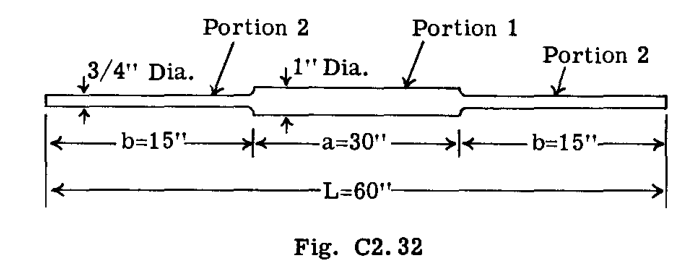

Fig. C2.32

| 部分 1 | 部分 2 |
| --- | --- |
| $A_1 = 0.7854\,\text{in.}^2$ | $A_2 = 0.4418$ |
| $I_1 = 0.0491\,\text{in.}^4$ | $I_2 = 0.0155$ |
| $E_c = 10,500,000$ | $E_c = 10,500,000$ |

Fig. C2.22 から、

$$P_{cr} = \frac{B(EI_1)}{L^2}$$

これは、弾性曲げ下での破壊に対するオイラーの式である。比 $a/L$ が 1 に等しいか、または一様断面である場合、 $B$ は Fig. C2.22 に示されるように $\pi^2$ または 10 になる。Fig. C2.22 の曲線は、弾性破壊にのみ適用される。Fig. C2.32 の部材はかなり細長いため、破壊は弾性的であると仮定し、その後この仮定をチェックする。

$$\frac{EI_1}{EI_2} = \frac{10,500,000 \times 0.0491}{10,500,000 \times 0.0155} = 3.17, \quad a/L = 30/60 = 0.5$$

$a/L = 0.5$ および $EI_1/EI_2 = 3.17$ に対する Fig. C2.22 から、 $B = 7.0$ を読み取る。

したがって、

$$P_{cr} = \frac{B\,EI_1}{L^2} = \frac{7 \times 10,500,000 \times 0.0491}{60^2} = 1000\,\text{lb.}$$

各部分における応力は以下の通りである。

$$f_1 = 1000/0.7854 = 1280\,\text{psi}$$

$$f_2 = 1000/0.4418 = 2270\,\text{psi}$$

これらの圧縮応力は材料の比例限度応力以下であるため、 $E_c$ は一定であり、我々の解法は正しい。

### ケース 2. 非弾性破壊

柱は Fig. C2.33 に示される寸法に短縮されている。直径および材料はケース 1 と同じままである。

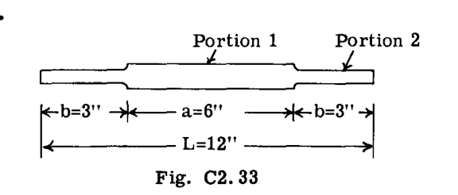

Fig. C2.33

これは比較的短い柱であるため、破壊応力は $E$ が一定ではない非弾性範囲に入るはずであり、したがって解法は試行錯誤の手順となる。我々は、平均 $L/\rho$ 値に基づいて最初の推測または試行を行う。

部分 1 に対する $\rho$ は 0.25 インチである。

部分 2 に対する $\rho$ は 0.1875 である。

$$\text{平均 } \rho = (6 \times 0.25 + 6 \times 0.1875) / 12 = 0.22$$

その場合、 $L/\rho = 12/0.22 = 54.5$ となり、55 を使用する。

Fig. C2.11 は、7075-T6 アルミ合金押出材の柱曲線である。 $L/\rho = 55$ を用いて、許容応力 $F_c = 33,500\,\text{psi}$ を読み取る。したがって、

$$P = F_c A = 33,500 \times 0.7854 = 26,300\,\text{lb.}$$

$$f_1 = 33,500 \quad \text{および} \quad f_2 = 26,300 / 0.4418 = 59,500$$

部分 2 における応力 $f_2$ は比例限度応力を超えているため、Fig. C2.22 の曲線を使用する際には塑性修正を行わなければならない。

第 Bl 章の Table B1.1 を参照すると、7075-T6 押出材に対して次の値が見つかる： $n = 16.6$ 、 $F_{o.7} = 72,000$ 、 $E_c = 10,500,000$ 。

応力 $f_1$ および $f_2$ に対する正接係数 $E_t$ が求められる。

部分 1 に対して、

$$f_1/F_{o.7} = 33,500/72,000 = 0.465$$

Fig. C2.16 を参照し、0.465 および $n = 16.6$ を使用すると、 $E_t/E = 1.0$ と読み取れ、したがって $E_t = E$ となり、部分 1 に対する塑性修正はない。

部分 2 に対して、

$$f_2/F_{o.7} = 59,500/72,000 = 0.826$$

Fig. C2.16 から、 $E_t/E = 0.675$ を得、そのとき $E_t = 0.675 \times 10,500,000 = 7,090,000$ となる。

$$\frac{EI_1}{EI_2} = \frac{10,500,000 \times 0.0491}{7,090,000 \times 0.0155} = 4.7$$

$a/L = 0.5$ に対する Fig. C2.22 から、 $B = 5.6$ を得る。

その場合、

$$P_{cr} = \frac{B\,EI_1}{L^2} = \frac{5.6 \times 10,500,000 \times 0.0491}{144} = 20,000\,\text{lb.}$$

我々が推測した強度は 26,300 lb であった。推測した強度と計算された強度は同じでなければならないため、もう一度試行する必要がある。

試行 2. 臨界荷重 $P = 23,500\,\text{lb}$ を仮定する。

$$f_1 = 23,500 / 0.7854 = 29,900$$

$$f_2 = 23,500 / 0.4418 = 53,100$$

部分 1：

$$f_1/F_{o.7} = 29,900 / 72,000 = 0.415$$

$n = 16.6$ に対する Fig. C2.16 から、 $E_t/E = 1.0$ を読み取る。

部分 2：

$$f_2/F_{o.7} = 53,100 / 72,000 = 0.738$$

Fig. C2.16 から、 $E_t/E = 0.90$ であり、したがって $E_t = 0.90 \times 10,500,000 = 9,450,000$ である。

$$\frac{EI_1}{EI_2} = \frac{10,500,000 \times 0.0491}{9,450,000 \times 0.0155} = 3.52$$

$a/L = 0.5$ に対する Fig. C2.22 から、 $B = 6.62$ を読み取る。

したがって、

$$P_{cr} = \frac{B\,EI_1}{L^2} = \frac{6.62 \times 10,500,000 \times 0.0491}{144} = 23,650\,\text{lb.}$$

これは実質的に仮定された値と一致しており、したがって答えは 23,500 から 23,650 の間であり、さらに精度が求められる場合は別の試行を行う必要がある。

Fig. C2.21、Fig. C2.23 および Fig. C2.24 に示されるような不均一断面を持つ他のタイプの柱も、同様の方法で解かれる。これらのチャートは、ピン支持端の柱にのみ使用される。テーパー付き柱の端部固定度係数 $c$ は、一様断面の柱の場合と同じではない。

## C2.13 既知の端部拘束モーメントを持つ柱強度

Fig. C2.27 は、既知の端部曲げ拘束の2つの条件について、端部固定度係数 $c$ を求めるための曲線を示している。

これらの曲線の使用法を説明するために、簡単な問題を解く。

Fig. C2.34 は、3ベイの溶接鋼管トラスを示している。問題は、部材 AB の許容圧縮応力を決定することである。この強度は、端部 A および B に存在する固定度によって影響を受ける。トラス内の各チューブの直径と肉厚は図に示されている。材料は AISI 鋼であり、 $F_{tu} = 90,000$ 、 $F_{ty} = 70,000$ 、 $E = 29,000,000$ である。

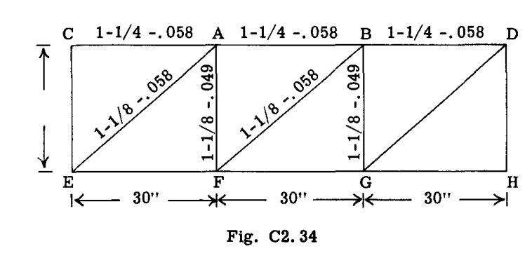

Fig. C2.34

部材 AB は、ジョイント (A) および (B) において3本の隣接するチューブに溶接されている。これらのチューブはジョイント (A) および (B) において同じであるため、部材 AB の端部 (A) および (B) における固定度は同じである。

Fig. C2.27 を参照すると、用語 $\mu$ は、ラジアンあたりのインチポンドで表される曲げ拘束係数ばね定数として定義されている。Fig. A において、遠端が固定されているときに端部 (A) を 1 ラジアン回転させるために必要なモーメント $M$ は $4EI/L$ である。

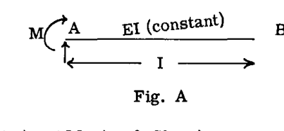

Fig. A

この値の導出については、第 A11 章の Art. A11.4 を参照されたい。遠端 (B) がピン支持されている場合（Fig. A）、モーメント $M = 3EI/L$ が端部 (A) を 1 ラジアン回転させる。わずかに保守的にするために、ジョイント (A) および (B) に入る部材の遠端はピン支持されていると仮定する。したがって $\mu = 3EI/L$ である。端部 (A) において部材 AB の支持を形成する 3 つの部材について、 $\mu = 3EI/L$ の合計が計算される。

部材 AC: $I = 0.03867, \quad I/L = 0.001289$ 部材 AE: $I = 0.02775, \quad I/L = 0.00071$ 部材 AF: $I = 0.02402, \quad I/L = 0.000962$

$$\mu = \sum 3EI/L$$

$$= 3(0.001289 + 0.00071 + 0.000962) \times 29,000,000 = 258,000$$

Fig. C2.27 では、項 $\mu L/EI$ が必要である。 $L/EI$ は部材 AB を指す。したがって、

$$\mu L/EI = (258,000 \times 30) / 29,000,000 \times 0.0367 = 7.28$$

部材 AB の両端における拘束が同じであるため、Fig. C2.27 の上側の曲線を使用する。したがって、 $\mu L/EI = 7.28$ に対して、端部固定度係数 $c = 2.58$ を読み取る。

その場合、 $L' = L/\sqrt{c} = 30/\sqrt{2.58} = 18.6$ である。

部材に対する $\rho = 0.422\,\text{inches}$ 。

$$L'/\rho = 18.6/0.422 = 44.0$$

Fig. C2.3 の柱曲線から、許容破壊応力 $F_c = 55,200\,\text{psi}$ を読み取る。

接続部材の遠端がピン支持ではなく固定されていると仮定された場合、 $\mu = 4EI/L$ となり、または前の値 7.28 に 4/3 を乗じることができ、これは 9.7 を与え、これを Fig. C2.27 で使用すると $c = 2.80$ を与える。

$$L'/\rho = 30/\sqrt{2.8} \times 0.422 = 42.5$$

その場合、Fig. C2.3 から $F_c = 56,600\,\text{psi}$ となる。遠端が固定に満たないため、遠端がピン支持されているという仮定は、かなり正確な結果を与える。

トラス構造では、すべての部材が軸荷重を支持しており、軸荷重は部材の端部の回転に抵抗する能力に影響を与える。第 A11 章の Art. A11.12 では、端部拘束係数 $\mu$ の計算で要求されるように、部材の剛性に対する軸荷重の影響を考慮する方法を説明している。

## C2.14 弾性横支持を持つ柱

Fig. C2.25 および Fig. C2.26 は、柱端部の中間点における弾性横支持を考慮するための端部固定度係数 $c$ を求めるための曲線を提供している。

これらのチャートの使用法を説明するために、直径 0.5 インチ、長さ 24 インチの丸棒が Fig. C2.35 に示されるように横方向に支持されている場合を考える。棒は AISI 鋼で作られており、熱処理されて $F_{tu} = 125,000$ となっている。横支持に対するばね定数は、インチあたり 775 lbs である。

1/2" 丸棒の慣性モーメント $I = 0.003068$ 回転半径 = 0.125 インチ

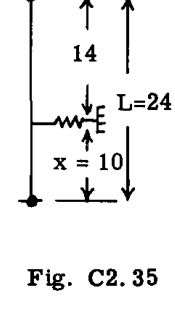

Fig. C2.35

$$q = \frac{K'L^3}{EI} = \frac{775 \times 24^3}{29,000,000 \times 0.003068} = 120$$

$x/L = 10/24 = 0.416$ および $q = 120$ に対する Fig. C2.25 から、我々は $c = 2.92$ を得る。

その場合、 $L' = L/\sqrt{c} = 24/\sqrt{2.92} = 14.08$ である。

$$L'/\rho = 14.08/0.125 = 113$$

$$F_c = \frac{\pi^2 E}{(L'/\rho)^2} = \frac{\pi^2 \times 29,000,000}{(113)^2} = 22,500\,\text{psi}$$

## C2.15 問題

1. 熱処理および時効処理された 6061-T6 アルミ合金シートは、以下の特性を持っている：
1. 室温下： $F_{o.7} = 35,000\,\text{psi}, \quad E_c = 10,100,000\,\text{psi}, \quad \text{and} \quad n = 31$
2. 300°F における 1/2 時間の暴露： $F_{o.7} = 29,000, \quad E_c = 9,500,000, \quad \text{and} \quad n = 26$

上記の2つのケース (a) および (b) について、Fig. C2.16 から $E_t$ （正接弾性係数）の値を決定し、これらの2つの材料条件に対する柱曲線を計算してプロットせよ。

2. Fig. C2.36 は、圧縮部材の断面を示している。以下のケースにおける破壊圧縮荷重を計算せよ：

ケース 1. $L = 25\,\text{inches}$ 。材料 AISI 鋼 4140、 $F_{tu} = 180,000$ 。端部固定度係数 $c = 1$ （ $x-x$ 軸まわりの曲げに対して）および 1.5（ $y-y$ 軸に対して）とする。

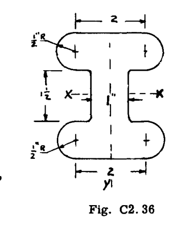

Fig. C2.36

3. 問題 (2) と同様、ただし部材が 850°F の温度に 1/2 時間さらされた場合。
4. 第 A3 章の Table A3.11 における Section No. 50 と同一の 2 つの押出チャンネル断面が、背中合わせにリベット接合され、柱部材として使用されている。部材が長さ 26 インチで、端部固定度が $c = 1$ 、材料が 7075-T6 押出材である場合、破壊圧縮荷重はいくらか。

部材が、固定度 $c = 2$ を提供する隣接する構造物に剛結されている場合、破壊荷重はいくらか。

5. 問題 (4) の柱が 2014-T6 アルミ合金押出材で作られていると仮定する。破壊荷重を求めよ。
6. Fig. C2.37 に示される両端ピン支持の単一ステップ柱は、AISI-4130 焼きならし鋼で作られており、 $F_{tu} = 90,000$ 、 $F_{cy} = 70,000$ である。部材が支持できる最大圧縮荷重を決定せよ。

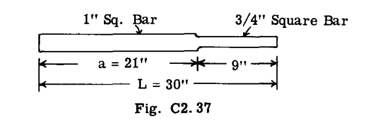

Fig. C2.37

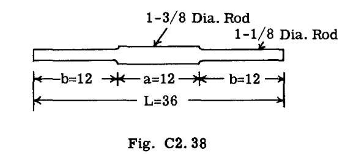

Fig. C2.38

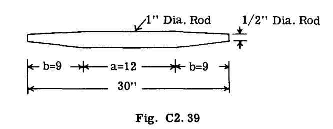

Fig. C2.39

### 参考文献

1. NACA Technical Note 902.
2. Non-dimensional Buckling Curves, by Cozzone & Melcon, Jr. of Aero. Sciences, October, 1946.
3. Chart from Lockheed Aircraft Structures Manual.